# 2018201743-张嘉辰-第七周作业

张嘉辰

2020年10月29日

# 2.8.9 Wilcoxon符号秩检验

```r
school <- c(82,69,73,43,58,56,76,65)
#将第八组的home的值改为82
home <- c(63,42,74,37,51,43,80,82)
response <- school - home
#进行Wilcoxon符号秩检验
wilcox.test(response, alternative="greater", conf.int=TRUE)
```

```
##
##  Wilcoxon signed rank test
##
## data:  response
## V = 27, p-value = 0.125
## alternative hypothesis: true location is greater than 0
## 95 percent confidence interval:
##   -4 Inf
## sample estimates:
## (pseudo)median
##           6.25
```

```r
#进行t检验
t.test(response, alternative="greater", conf.int=TRUE)
```

```
##
##  One Sample t-test
##
## data:  response
## t = 1.2789, df = 7, p-value = 0.1209
## alternative hypothesis: true mean is greater than 0
## 95 percent confidence interval:
##  -3.00903      Inf
## sample estimates:
## mean of x
##      6.25
```

# 2.8.10 污染正态分布

## (1)从CN(c,ε)中抽样的函数

```r
#得到n个服从CN(c, ε)的随机数
CN_samp_func <- function(n, c, eps){
  set.seed(1234)
#从成功概率为eps的二项分布中抽样
  choice <- rbinom(n, 1, prob = eps)
#试验成功则有choice=1，此时从N(0, c^2)中选取样本
#试验失败则有choice=0，此时从N(0, 1)中选取样本
#由于ifelse()函数只运行参数yes和no中的rnorm各一次，所以choice=0或1的情况都需要产生n个（而不是1个）服从正态分布的随机数，否则同一个随机数将会重复出现。
#返回n个服从CN(c, ε)的随机数
  return(ifelse(choice == 0, yes = rnorm(n, 0, 1), no = rnorm(n, 0, c)))
}
```

## (2)抽样并进行对比

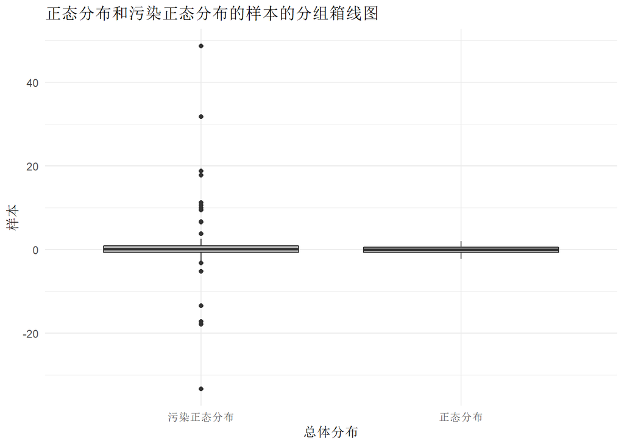

```r
#样本量
n <- 100
#从正态分布中抽样
norm_samp <- rnorm(n, 0, 1)
#从污染正态分布中抽样
cn_samp <- CN_samp_func(n, 16, 0.25)
#构建包含样本的数据框
#第一列为因子类型，表示样本来自的分布为正态分布或者污染正态分布
#第二列为样本值
samp_df <- data.frame(
  distr = as.factor(c(rep("正态分布", n), rep("污染正态分布", n))),
  samp_value = c(norm_samp, cn_samp)
)


library(ggplot2)
library(dplyr)
library(hrbrthemes)
#画出正态分布和污染正态分布的样本的分组箱线图
ggplot(samp_df, aes(x = distr, y = samp_value)) +
  geom_boxplot(fill = "grey") +
  theme_minimal() +
  labs(x = "总体分布", y = "样本",
       title = "正态分布和污染正态分布的样本的分组箱线图")
```

从正态分布和污染正态分布的样本的分组箱线图中可以看到，

来自两个分布的样本的箱子的厚度、位置都大致接近，

但是来自污染正态分布中的样本出现较多异常值。

由于异常值的存在，箱子被压扁，所以接下来去除异常值后再画出分组箱线图，以观察箱子的差异。

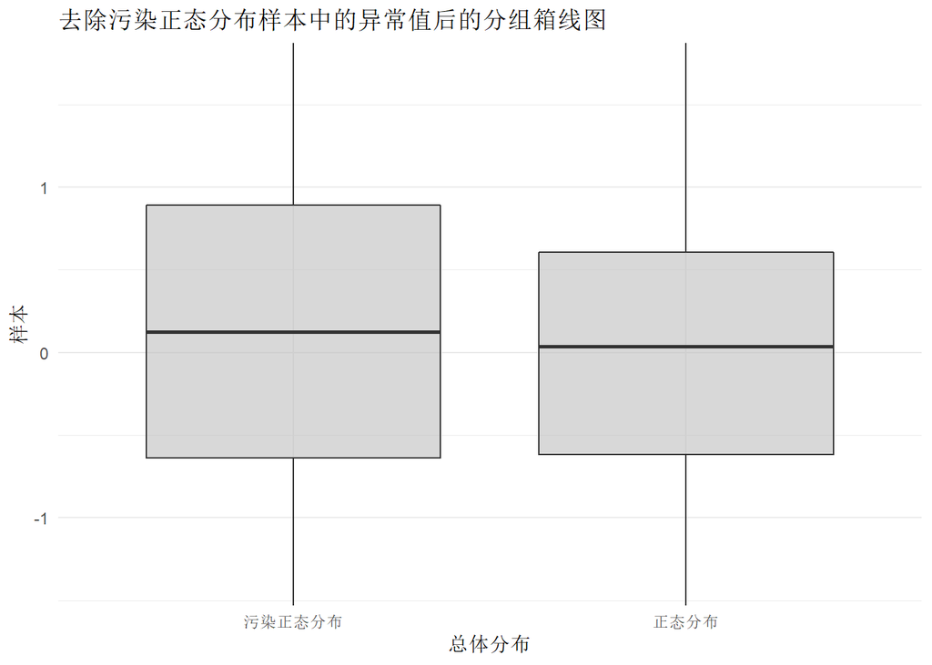

```r
#去除污染正态分布样本中的异常值后的分组箱线图
ggplot(samp_df, aes(x = distr, y = samp_value)) +
#去除异常值
  geom_boxplot(fill = "grey", alpha = 0.6, outlier.shape = NA) +
#调整y轴的范围
  coord_cartesian(ylim = quantile(samp_df$samp_value, c(0.1, 0.9))) +
  theme_minimal() +
  labs(x = "总体分布", y = "样本",
       title = "去除污染正态分布样本中的异常值后的分组箱线图")
```

由于样本量较小，去除异常值后，两者的箱子没有不是以0为对称轴的对称形状。

这是由于抽样的偶然性。在增大样本量后，箱子将会接近对称。

接下来画出正态分布和污染正态分布的样本的直方图。

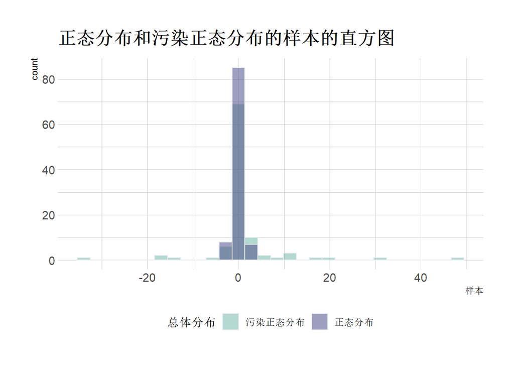

```r
ggplot(samp_df, aes(x=samp_value, fill=distr)) +
  geom_histogram( color="#e9ecef", alpha=0.5, position = 'identity') +
  theme_ipsum() +
#图例位置
  theme(legend.position = "bottom") +
#设置图例标签
  scale_fill_manual(name = "总体分布", labels = c("污染正态分布", "正态分布"), values=c("#69b3a2", "#404080")) +
  labs(fill="", x = "样本", title = "正态分布和污染正态分布的样本的直方图")
```

从直方图中可以看出，来自污染正态分布和正态分布的样本都集中在0附近

但是来自污染正态分布的样本出现较多异常值。

# 2.8.12 统计量的有效性

```r
#每组的样本量为n
n <- 30
#共抽取nsims组样本
nsims <- 10000
#从标准正态分布中抽取样本，每一行为一组样本，共nsims行
x_samp_norm <- matrix(rnorm(n*nsims), nrow = nsims, ncol = n)
#从自由度为2的t分布中抽取样本，每一行为一组样本，共nsims行
x_samp_t <- matrix(rt(n*nsims, df = 2), nrow = nsims, ncol = n)

#计算HL统计量的置信区间长度的平方
CI_wil_func <- function(data){
  wil_test <- wilcox.test(data, conf.int = TRUE)
  return((wil_test$conf.int[2]-wil_test$conf.int[1])^2)
}
#计算样本均值的置信区间长度的平方
CI_t_func <- function(data){
  t_test <- t.test(data, conf.int = TRUE)
  return((t_test$conf.int[2]-t_test$conf.int[1])^2)
}

#总体为标准正态分布时，计算两种统计量构建的置信区间的长度平方的均值之比
effi_norm <- mean(apply(x_samp_norm, 1, CI_wil_func))/mean(apply(x_samp_norm, 1, CI_t_func))
effi_norm
```

```
## [1] 1.051014
```

```r
#总体为自由度为2的t分布时，计算两种统计量构建的置信区间的长度平方的均值之比
effi_t <- mean(apply(x_samp_t, 1, CI_wil_func))/mean(apply(x_samp_t, 1, CI_t_func))
effi_t
```

```
## [1] 0.07308993
```

# 2.8.14 显著性水平、势

## (1)显著性水平

分别计算显著性水平的理论值和经验值。

```r
#由于已知为二项分布，所以可以计算显著性水平的理论值
#显著性水平等于在n=75,p=0.3的二项分布中，成功次数小于等于16的概率
sig <- pbinom(16, 75, 0.3)
sig
```

```
## [1] 0.06199817
```

```r
#也可以多次抽样，计算显著性水平的经验值
#样本量为n
n <- 100000

set.seed(1234)
#从二项分布中抽样，得到成功次数
succ_num <- rbinom(nsims, 75, 0.3)
#成功次数小于等于16则拒绝原假设
sig_trial <- sum(succ_num<=16)/nsims
#得到显著性水平的经验值
sig_trial
```

```
## [1] 0.0622
```

## (2)势

分别计算势的理论值和经验值。

```r
#计算势的理论值
#势等于n=75,p=0.25的二项分布中，成功次数小于等于16的概率
power_test <- pbinom(16, 75, 0.25)
power_test
```

```
## [1] 0.2792418
```

```r
#也可以多次抽样，计算势的经验值
set.seed(1234)
#样本量为n
n <- 100000
#真实的p
p_true <- 0.25
#从二项分布中抽样，得到成功次数
trial <- rbinom(nsims, 75, p_true)
#成功次数小于等于16则拒绝原假设
power_trial <- sum(trial <= 16)/nsims
#得到势的经验值
power_trial
```

```
## [1] 0.2775
```

## (3)画图

可以分别采用势的理论值和经验值画图，图形非常接近。

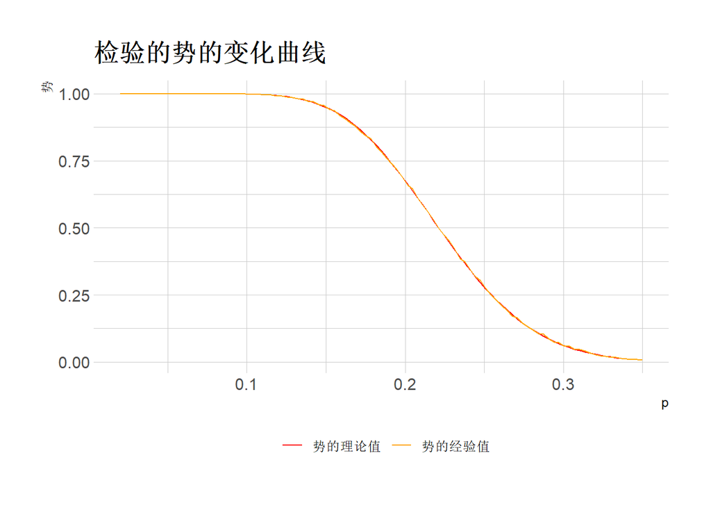

```r
p_seq <- seq(from = 0.02, to = 0.35, by = 0.01)
#每一组的样本量为n
n <- 10000

set.seed(1234)

#计算势的理论值
power_func_theo <- function(p){
  return(pbinom(16, 75, p))
}
#计算势的经验值
power_func_empi <- function(p){
  trial <- rbinom(n, 75, p)
  power_trial <- (sum(trial <= 16))/n
  return(power_trial)
}

power_df_func_empi <- function(p){
  sapply(p, power_func_empi)
}
#构建数据框，用来画图
plot.range.theo <- data.frame(x=p_seq, Functions = factor(1))
plot.range.empi <- data.frame(x=p_seq, Functions = factor(2))

library(ggplot2)
library(hrbrthemes)
#画出检验的势的变化曲线
ggplot(NULL, aes(x=x, color = Functions)) +
#画出检验的势的理论值的变化曲线，颜色为红色
  geom_function(data = plot.range.theo, fun = power_func_theo)+
#画出检验的势的经验值的变化曲线，颜色为橙色
  geom_function(data = plot.range.empi, fun = power_df_func_empi) +
  scale_colour_manual(values = c("red", "orange"),
                      labels = c("势的理论值", "势的经验值"),
                      name = "") +
  theme_ipsum() +
  theme(legend.position = "bottom") +
  labs(title="检验的势的变化曲线",
       y = "势", x="p")
```

势的经验值和理论值几乎重合。

# 2.8.16 Wald检验、Score检验

原假设和备择假设为

$H_0:p_1=p_2$ $v.s.$ $H_1:p_1>p_2$

## (1)Wald检验

Wald检验的检验统计量为

$$T S=\frac{\hat{p}_{1}-\hat{p}_{2}}{\sqrt{\frac{\hat{p}_{1}\left(1-\hat{p}_{1}\right)}{n_{1}}+\frac{\hat{p}_{2}\left(1-\hat{p}_{2}\right)}{n_{2}}}}$$

在$n_1,n_2$较大时，该统计量近似服从正态分布。

## (2)Score检验

Score检验的检验统计量为

$$T S=\frac{\hat{p}_{1}-\hat{p}_{2}}{\sqrt{\hat{p}(1-\hat{p})\left(\frac{1}{n_{1}}+\frac{1}{n_{2}}\right)}}$$

其中
$$\hat{p}=\frac{X+Y}{n_1+n_2}=\frac{n_1 \hat{p}_{1}+n_2 \hat{p}_{2}}{n_1+n_2}$$

是在原假设成立的条件下，即$p_1=p_2=p$时，用合样本的频率来估计共同的$p$。

在$n_1,n_2$较大时，该统计量近似服从正态分布。

```r
set.seed(1234)

#共抽取nsims组样本
nsims <- 10000

p1 <- 0.6
p2 <- 0.5

#记录每组样本进行Wald检验的p值
p_wald_samp <- rep(0, nsims)
#记录每组样本进行Score检验的p值
p_score_samp <- rep(0, nsims)
#记录每组样本进行Wald检验的p值是否小于0.05，小于则为1，否则为0
pow_wald <- rep(0, nsims)
#记录每组样本进行Score检验的p值是否小于0.05，小于则为1，否则为0
pow_score <- rep(0, nsims)


for(i in 1:nsims){
#从总体1中抽样
  samp1 <- rbinom(1, 50, p1)
#从总体2中抽样
  samp2 <- rbinom(1, 50, p2)

#p1的估计值
  p1_hat <- samp1/50
  p1_hat
#p2的估计值
  p2_hat <- samp2/50
  p2_hat
#在原假设成立时，p=p1=p2的估计值
  p_hat <- (samp1+samp2)/(50+50)

#Wald检验的检验统计量
  TS_wald <- (p1_hat-p2_hat)/(sqrt((p1_hat*(1-p1_hat)/50)+(p2_hat*(1-p2_hat)/50)))
#wald检验的p值（用正态分布近似）
  p_wald <- 1 - pnorm(TS_wald)
  p_wald_samp[i] <- p_wald
}

#score检验的检验统计量
  TS_score <- (p1_hat-p2_hat)/(sqrt(p_hat*(1-p_hat)*(1/50+1/50)))
#score检验的p值（用正态分布近似）
  p_score <- 1 - pnorm(TS_score)
  p_score_samp[i] <- p_score

#计算Wald检验的势
pow_wald[p_wald_samp <= 0.05] <- 1
power_wald <- sum(pow_wald)/nsims
#计算Score检验的势
pow_score[p_score_samp <= 0.05] <- 1
power_score <- sum(pow_score)/nsims

#输出结果
knitr::kable(data.frame("Wald检验的势"=power_wald, "Score检验的势"=power_score),
             format = "html")
```

| Wald检验的势 | Score检验的势 |
| --- | --- |
| 0.2465 | 0.9999 |

# 2.8.25 Bonferroni同时置信区间

## (1)两个置信区间

由德・摩根定律
$$P\left(A_{1} \cap A_{2}\right)=1-P\left(A_{1} \cup A_{2}\right)$$

由 Boole 不等式

$$P\left(A_{1}^{\prime} \cup A_{2}^{\prime}\right) \leq P\left(A_{1}^{\prime}\right)+P\left(A_{2}^{\prime}\right)$$

已知

$${P_{\theta_{i}}}\left[\theta_{i} \in I_{i}\right]=1-\frac{\alpha}{2}, \quad i=1,2$$

用 $A_{i}$ 表示事件 $\theta_{i} \in I_{i} ,\ i=1,2$

得到

$$P_{\theta_{1}, \theta_{2}}\left[\left\{\theta_{1} \in I_{1}\right\} \cap\left\{\theta_{2} \in I_{2}\right\}\right] \geq 1-\left[P\left(A_{1}^{\prime}\right)+P\left(A_{2}^{\prime}\right)\right]=1-\left(\frac{\alpha}{2}+\frac{\alpha}{2}\right)=1-\alpha$$

$$P_{\theta_{1}, \theta_{2}}\left[\left\{\theta_{1} \in I_{1}\right\} \cap\left\{\theta_{2} \in I_{2}\right\}\right] \geq 1-\alpha$$

## (2)推广到m个置信区间

由德・摩根定律

$$P\left(A_{1} \cap A_{2} \cap \ldots \cap A_{m}\right)=1-P\left(A_{1}^{\prime} \cup A_{2}^{\prime} \cup \ldots \cup A_{m}^{\prime}\right)$$

Bonferroni不等式

$$P\left(A_{1}^{\prime} \cup A_{2}^{\prime} \cup \ldots \cup A_{m}^{\prime}\right) \leq \sum_{i=1}^{m} P\left(A_{i}^{\prime}\right)$$

因此，有

$$P\left(A_{1} \cap A_{2} \cap \ldots \cap A_{m}\right) \geq 1-\sum_{i=1}^{m} P\left(A_{i}^{\prime}\right)$$

已知

$$P\left(\theta_{j} \in I_{j}\right)=1-\left(\frac{\alpha}{2}\right), j=1,2, \ldots, \mathrm{m}$$

用 $A_{j}$ 表示事件 $\theta_{j} \in I_{j}$

则由 Bonferroni不等式得到

$$P\left(\theta_{1} \in I_{1}, \theta_{2} \in I_{2}, \ldots \theta_{m} \in I_{m}\right) \geq 1-\sum_{i=1}^{m} P\left(\theta_{j} \notin I_{j}\right) \quad=1-\sum_{i=1}^{m} \frac{\alpha}{2}=1-\frac{m \alpha}{2}$$

$$P\left(\theta_{1} \in I_{1}, \theta_{2} \in I_{2}, \ldots \theta_{m} \in I_{m}\right) \geq 1-\frac{m \alpha}{2}$$

# 2.11 Bootstrap方法

参数$\mu$的极大似然估计是$\overline{X}$

根据极大似然估计的不变原理，得到

$\theta=e^{\mu}$的极大似然估计为$\hat{\theta}=e^{\overline{X}}$

## (1)抽取样本

```r
#样本量为n
n <- 100

set.seed(19)
#抽取样本
x_samp <- rnorm(n, 5, 1)

#θ的真实值
theta_true <- exp(5)
theta_true
```

```
## [1] 148.4132
```

## (2)参数Bootstrap方法

在已知总体分布为正态分布的前提下，可以采用参数Bootstrap方法。

用$\mu$的极大似然估计$\overline{X}$代替$\mu$，

再从$N(\overline{X},1)$中抽样。

再根据

$$C_{n}=\left(2 \hat{\theta}_{n}-\hat{\theta}_{1-\frac{\alpha}{2}}^{*}, 2 \hat{\theta}_{n}-\hat{\theta}_{\frac{\alpha}{2}}^{*}\right)$$

得到$1-\alpha$ Bootstrap 枢轴量置信区间。

```r
#参数Bootstrap方法

#一共抽取nsims组样本
nsims <- 10000
#参数Bootstrap方法每组的样本量
n_para <- 30

#均值μ的极大似然估计为样本均值
x_bar_est <- mean(x_samp)
x_bar_est
```

```
## [1] 5.012585
```

```r
#用均值μ的极大似然估计代替μ，得到N(x_bar, 1)，再从中抽样
x_bar_boot_para <- replicate(nsims, expr = {
    y <- rnorm(n_para, x_bar_est, 1)
    return(mean(y))
})
#使用参数Bootstrap方法得到的θ的估计值
theta_est_boot_para <- exp(mean(x_bar_boot_para))


#枢轴量法计算置信区间
#置信下限
L_para <- exp(2*mean(x_bar_boot_para)-quantile(x_bar_boot_para, 0.975))
names(L_para) <- NULL
#置信上限
U_para <- exp(2*mean(x_bar_boot_para)-quantile(x_bar_boot_para, 0.025))
names(U_para) <- NULL

#估计的标准差
sd_para <- sd(exp(x_bar_boot_para))

#输出结果
knitr::kable(data.frame("参数方法的θ的估计值" = theta_est_boot_para,
  "参数方法的置信下限" = L_para,
  "参数方法的置信上限" = U_para,
  "参数方法的估计标准差" = sd_para ),
  format = "html")
```

| 参数方法的θ的估计值 | 参数方法的置信下限 | 参数方法的置信上限 | 参数方法的估计标准差 |
| --- | --- | --- | --- |
| 150.2839 | 104.0327 | 214.7695 | 28.29006 |

## (3)非参数Bootstrap方法

从已有的样本x_samp中重复进行有放回的抽样，

再根据

$$C_{n}=\left(2 \hat{\theta}_{n}-\hat{\theta}_{1-\frac{\alpha}{2}}^{*}, 2 \hat{\theta}_{n}-\hat{\theta}_{\frac{\alpha}{2}}^{*}\right)$$

得到$1-\alpha$ Bootstrap 枢轴量置信区间

```r
#非参数Bootstrap方法

#一共抽取nsims组样本
nsims <- 10000
#非参数Bootstrap方法每组的样本量
n_non <- 30
#从已有的样本x_samp中有放回地抽样
#得到每组样本的均值
x_bar_boot_non <- replicate(nsims, expr = {
    y <- sample(x_samp, size = n_non, replace = TRUE)
    return(mean(y))
})

#使用非参数Bootstrap方法得到的θ的估计值
theta_est_boot_non <- exp(mean(x_bar_boot_non))
#使用枢轴量法得到置信区间
#置信下限
L_non <- exp(2*mean(x_bar_boot_non)-quantile(x_bar_boot_non, 0.975))
names(L_non) <- NULL
#置信上限
U_non <- exp(2*mean(x_bar_boot_non)-quantile(x_bar_boot_non, 0.025))
names(U_non) <- NULL

#估计的标准差
sd_non <- sd(exp(x_bar_boot_non))

#输出结果
knitr::kable(data.frame("非参数方法的θ的估计值" = theta_est_boot_non,
  "非参数方法的置信下限" = L_non,
  "非参数方法的置信上限" = U_non,
  "非参数方法的估计标准差" = sd_non),
  format = "html")
```

| 非参数方法的θ的估计值 | 非参数方法的置信下限 | 非参数方法的置信上限 | 非参数方法的估计标准差 |
| --- | --- | --- | --- |
| 150.1687 | 103.6191 | 217.0858 | 28.78219 |

参数和非参数Bootstrap方法结果的比较：

两者的结果较为接近。

通常在相同的样本量和抽样次数下，参数Bootstrap方法的估计标准误比参数Bootstrap方法更小，置信区间也更短。

这是由于已知总体分布（此题中已知总体为正态分布），参数Bootstrap方法从已知的分布类型中抽样，得到的估计的的方差更小。

但是，如果已知的总体分布是错误的，则参数Bootstrap方法得到的估计虽然方差小，但是会有较大的偏差。

因此，在正确地已知总体分布时，采用参数Bootstrap方法将得到标准差更小的估计；

否则非参数Bootstrap方法更好。

## (4)观测的直方图

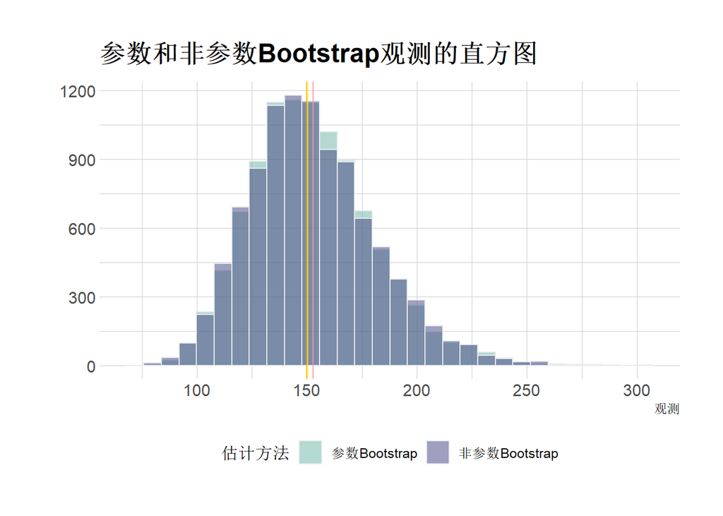

```r
library(ggplot2)
library(dplyr)
library(hrbrthemes)
#构建包含参数和非参数Bootstrap观测的数据框
#第一列为因子类型，表示改观测来自参数或者非参数Bootstrap方法
#第二列为观测值
samp_df <- data.frame(
  method = as.factor(c(rep("参数Bootstrap", nsims), rep("非参数Bootstrap", nsims))),
  value = c(exp(x_bar_boot_para), exp(x_bar_boot_non))
)

#画出参数和非参数Bootstrap观测的直方图
ggplot(samp_df, aes(x=value, fill=method)) +
  geom_histogram( color="#e9ecef", alpha=0.5, position = 'identity') +
#标出非参数Bootstrap观测的均值，颜色为红色
  geom_vline(xintercept = mean(exp(x_bar_boot_non)), col = "red", alpha = 0.7) +
#标出非参数Bootstrap观测的中位数，颜色为黄色
  geom_vline(xintercept = median(exp(x_bar_boot_non)), col = "orange", alpha = 0.7) +
#标出参数Bootstrap观测的均值，颜色为粉色
  geom_vline(xintercept = mean(exp(x_bar_boot_para)), col = "pink", alpha = 0.7) +
#标出非参数Bootstrap观测的均值，颜色为黄色
  geom_vline(xintercept = median(exp(x_bar_boot_para)), col = "yellow", alpha = 0.7) +
  theme_ipsum() +
#设置图例位置
  theme(legend.position = "bottom") +
#设置图例标签
  scale_fill_manual(name = "估计方法", labels = c("参数Bootstrap", "非参数Bootstrap"), values=c("#69b3a2", "#404080")) +
  labs(fill="", x = "观测", y = "", title = "参数和非参数Bootstrap观测的直方图")
```

（由于非参数和参数Bootstrap观测的均值非常接近，所以图中的两条均值线（红色和粉色）重叠了）

从图中可以看出，非参数和参数Bootstrap观测的均值均大于对应的中位数。

$\hat{\theta}$的分布是右偏的。